# Дополнительные возможности работы в Jupyter Notebook

### Можно вызывать bash команды

Для выполнения bash команд в блокноте необходимо поставить "!" перед комнадой.

Пример установки библиотеки numpy с помощью bash команды в блокноте. В результате выполнения команды в виртуальное окружение блокнота будет установле библиотека numpy.

```python
!pip install numpy
```

Для просмотра файлов и папок в текущей директории выполним следующую команду:

```python
!ls
```

```
example_jupyter.ipynb  introduction2jupyter.ipynb  README.md  temp
```

### Управление выводом результата выражения в последней строке ячейки

Для запрета вывода результатов в конце строки ставится ";". Иначе будет выведен результат выражения последней строки ячейки

```python
x = 8
x * x
```

```
64
```

```python
"Hello word"
```

```
'Hello word'
```

Если необходимо вывести информацию не из последней строки ячейки, то необходимо использовать функцию print()

```python
print("line 1")
x = 3
```

```
line 1
```

Вывод информации в цикле можно организовать следующим образом:

```python
for i in range(5):
    print(i)
```

```
0
1
2
3
4
```

### Некоторые полезные опции

Информация о функциях можно посмотреть с помощью "?".

Посмотрим информацию о функции math.exp.

```python
import math
math.exp?
```

Если выполнить предыдущую ячейку, то внизу блокнота будет открыта информации о функции math.exp

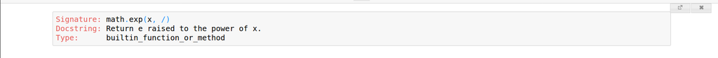

Информация о горящих клавишах доступна: Help > Keyboard Shortcuts

## Магические команды

Под магией в Jupyter понимаются дополнительные команды, выполняемые в рамках оболочки, которые облегчают процесс разработки и расширяют возможности.

Этим командам предшевствует знак %

Краткая справка о IPython доступна с помощью команды %quickref

```python
%quickref
```

Подробная документация по всем имеющимся магическим командам

```python
%magic
```

```python
%lsmagic
```

```
Available line magics:
%alias  %alias_magic  %autoawait  %autocall  %automagic  %autosave  %bookmark  %cat  %cd  %clear  %colors  %conda  %config  %connect_info  %cp  %debug  %dhist  %dirs  %doctest_mode  %ed  %edit  %env  %gui  %hist  %history  %killbgscripts  %ldir  %less  %lf  %lk  %ll  %load  %load_ext  %loadpy  %logo…

Available cell magics:
%%!  %%HTML  %%SVG  %%bash  %%capture  %%debug  %%file  %%html  %%javascript  %%js  %%latex  %%markdown  %%perl  %%prun  %%pypy  %%python  %%python2  %%python3  %%ruby  %%script  %%sh  %%svg  %%sx  %%system  %%time  %%timeit  %%writefile

Automagic is ON, % prefix IS NOT needed for line magics.
```

Для подсчета времени выполнения одной строки используется %time.

```python
import random
%time random.randint(0, 100)
```

```
CPU times: user 15 µs, sys: 0 ns, total: 15 µs
Wall time: 19.1 µs
```

```
89
```

Перед магическими командами для одной строки в ячейке ставится `%`.  
Перед магическими командами для всей ячейки ставится `%%`.

```python
%time
res = []     # вычисляется время только для этой строки
for i in range(100000):
    res.append(i)
```

```
CPU times: user 5 µs, sys: 1 µs, total: 6 µs
Wall time: 8.34 µs
```

```python
%%time
res = []   # вычисляется время для всей ячейки
for i in range(100000):
    res.append(i)
```

```
CPU times: user 18.9 ms, sys: 0 ns, total: 18.9 ms
Wall time: 20.4 ms
```

Для выполния предложения несколько раз и усредния времени работы строки используется команда %timeit

```python
%timeit random.randint(0, 100)
```

```
1.15 µs ± 61.9 ns per loop (mean ± std. dev. of 7 runs, 1000000 loops each)
```

Вывести переменные, определенные в интерактивном пространстве имен можно с помощью команды %who

```python
%who
```

```
i	 math	 random	 x
```

Вывести переменные, определенные в интерактивном пространстве имен в виде списка можно с помощью команды %who_ls

```python
%who_ls
```

Результат магических команд можно присваивать переменным.

Присвоим список всех имен в интерактивном пространстве переменной names.

```python
names = %who_ls
names
```

[output not shown]

Удаление переменной и очистка всех ссылок на объект осуществляется с помощью команды %xdel

```python
%xdel x
%who
```

[output not shown]

И в результате обращения к данной переменной происходит ошибка

```python
x * x
```

```
---------------------------------------------------------------------------
NameError                                 Traceback (most recent call last)
<ipython-input-35-0dcf3a591295> in <module>
----> 1 x * x

NameError: name 'x' is not defined
```